# Gráfico de Barras ou Colunas Agrupadas:

Variáveis: Qualitativas (categóricas) e Quantitativas. Uso: Compara valores quantitativos para diferentes categorias qualitativas.

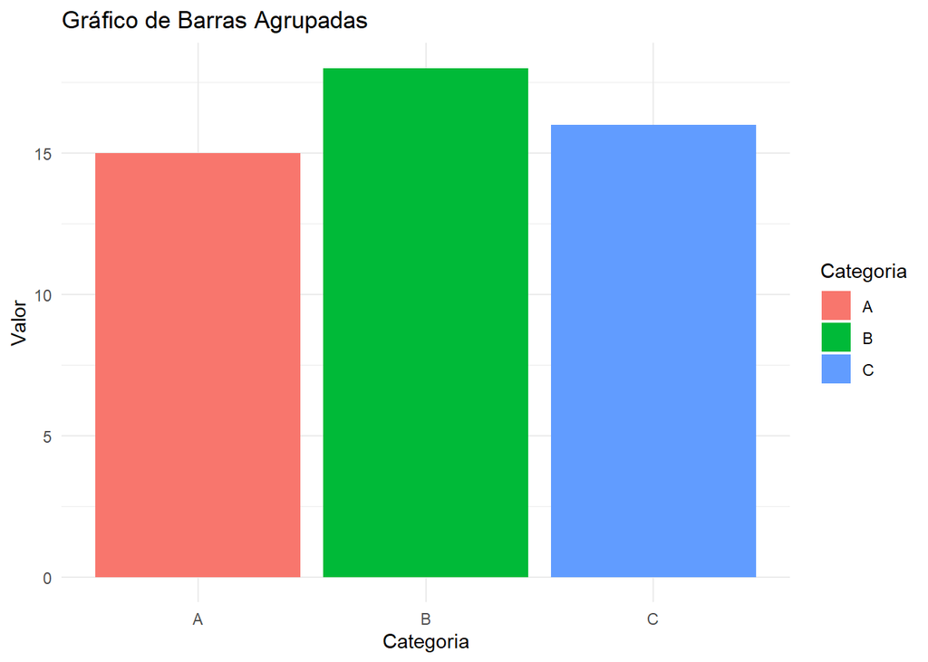

```r
# Instale o pacote ggplot2 se ainda não estiver instalado
#  install.packages("tidyverse")

# Carregue o pacote ggplot2
library(ggplot2)

# Crie um conjunto de dados fictício
dados <- data.frame(
  Categoria = rep(c("A", "B", "C"), each = 4),
  Valor = c(10, 15, 8, 12, 14, 18, 9, 13, 11, 16, 7, 10)
)

# Crie o gráfico de barras agrupadas
ggplot(dados, aes(x = Categoria, y = Valor, fill = Categoria)) +
  geom_bar(stat = "identity", position = "dodge") +
  labs(title = "Gráfico de Barras Agrupadas",
       x = "Categoria",
       y = "Valor") +
  theme_minimal()
```

## Colunas Agrupadas

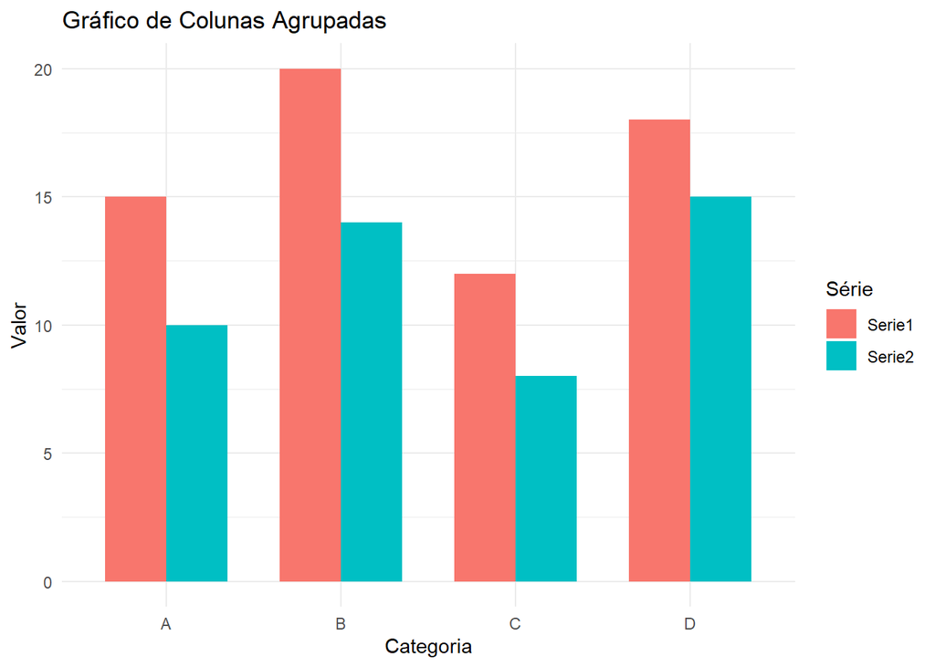

```r
# Instale o pacote ggplot2 se ainda não estiver instalado
# install.packages("ggplot2")

# Carregue o pacote ggplot2
library(ggplot2)

# Crie um conjunto de dados fictício com duas séries
dados <- data.frame(
  Categoria = c("A", "B", "C", "D"),
  Serie1 = c(15, 20, 12, 18),
  Serie2 = c(10, 14, 8, 15)
)

# Converta os dados para o formato longo
dados_long <- tidyr::gather(dados, key = "Serie", value = "Valor", -Categoria)

# Crie o gráfico de colunas agrupadas
ggplot(dados_long, aes(x = Categoria, y = Valor, fill = Serie)) +
  geom_col(position = "dodge", width = 0.7) +
  labs(title = "Gráfico de Colunas Agrupadas",
       x = "Categoria",
       y = "Valor",
       fill = "Série") +
  theme_minimal()
```

# Gráfico de Barras Empilhadas:

Variáveis: Qualitativas (categóricas) e Quantitativas. Uso: Mostra a contribuição relativa de diferentes categorias para o total.

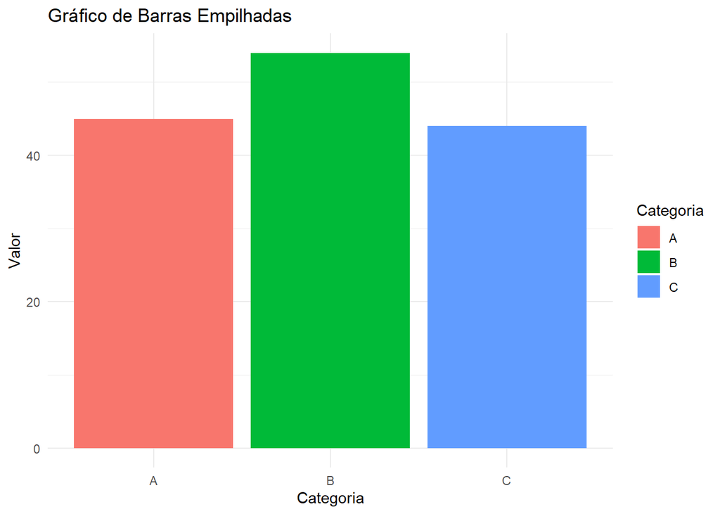

```r
# Instale o pacote ggplot2 se ainda não estiver instalado
# install.packages("ggplot2")

# Carregue o pacote ggplot2
library(ggplot2)

# Crie um conjunto de dados fictício
dados <- data.frame(
  Categoria = rep(c("A", "B", "C"), each = 4),
  Valor = c(10, 15, 8, 12, 14, 18, 9, 13, 11, 16, 7, 10)
)

# Crie o gráfico de barras empilhadas
ggplot(dados, aes(x = Categoria, y = Valor, fill = Categoria)) +
  geom_bar(stat = "identity") +
  labs(title = "Gráfico de Barras Empilhadas",
       x = "Categoria",
       y = "Valor") +
  theme_minimal()
```

# Gráfico de barras empilhadas:

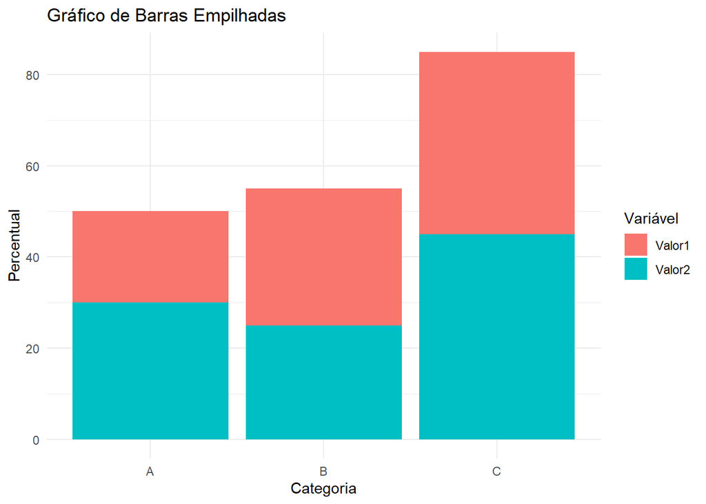

```r
# Instale o pacote ggplot2 se ainda não estiver instalado
# install.packages("ggplot2")

# Carregue o pacote ggplot2
library(ggplot2)

# Crie um conjunto de dados fictício
dados <- data.frame(
  Categoria = c("A", "B", "C"),
  Valor1 = c(20, 30, 40),
  Valor2 = c(30, 25, 45)
)

# Transforme os dados para o formato longo
dados_long <- tidyr::gather(dados, key = "Variavel", value = "Percentual", -Categoria)

# Crie o gráfico de barras empilhadas
ggplot(dados_long, aes(x = Categoria, y = Percentual, fill = Variavel)) +
  geom_bar(stat = "identity") +
  labs(title = "Gráfico de Barras Empilhadas",
       x = "Categoria",
       y = "Percentual",
       fill = "Variável") +
  theme_minimal()
```

# Diagrama de Dispersão:

Variáveis: Duas variáveis quantitativas. Uso: Mostra a relação ou correlação entre duas variáveis quantitativas.

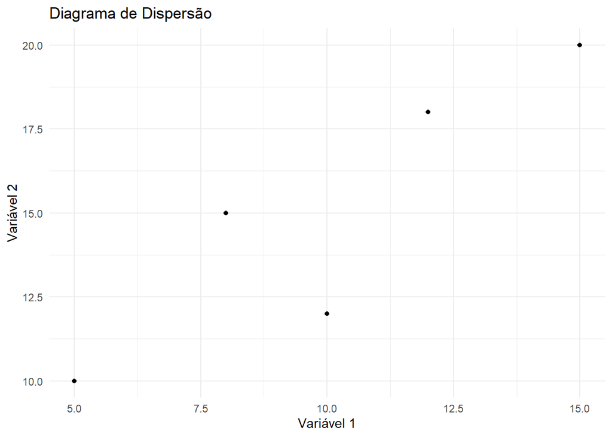

```r
# Instale o pacote ggplot2 se ainda não estiver instalado
# install.packages("ggplot2")

# Carregue o pacote ggplot2
library(ggplot2)

# Crie um conjunto de dados fictício
dados <- data.frame(
  Variavel1 = c(5, 8, 10, 12, 15),
  Variavel2 = c(10, 15, 12, 18, 20)
)

# Crie o diagrama de dispersão
ggplot(dados, aes(x = Variavel1, y = Variavel2)) +
  geom_point() +
  labs(title = "Diagrama de Dispersão",
       x = "Variável 1",
       y = "Variável 2") +
  theme_minimal()
```

Gráfico de Linhas:

Variáveis: Qualitativas (tempo) e Quantitativas. Uso: Exibe tendências ao longo do tempo ou de outra variável qualitativa.

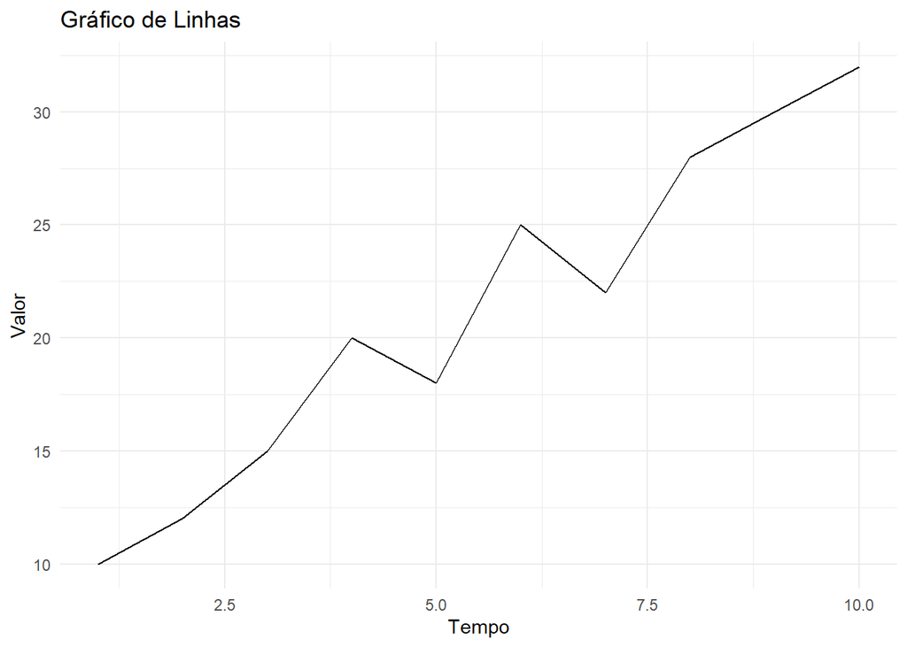

```r
# Instale o pacote ggplot2 se ainda não estiver instalado
# install.packages("ggplot2")

# Carregue o pacote ggplot2
library(ggplot2)

# Crie um conjunto de dados fictício
dados <- data.frame(
  Tempo = seq(1, 10),
  Valor = c(10, 12, 15, 20, 18, 25, 22, 28, 30, 32)
)

# Crie o gráfico de linhas
ggplot(dados, aes(x = Tempo, y = Valor)) +
  geom_line() +
  labs(title = "Gráfico de Linhas",
       x = "Tempo",
       y = "Valor") +
  theme_minimal()
```

Box Plot (Diagrama de Caixa):

Variáveis: Qualitativas (categóricas) e Quantitativas. Uso: Representa a distribuição estatística dos dados, destacando a mediana, quartis e outliers.

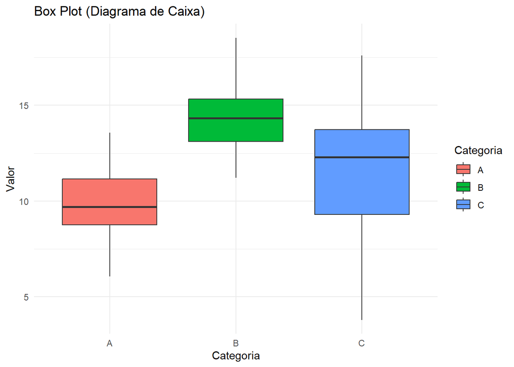

```r
# Instale o pacote ggplot2 se ainda não estiver instalado
# install.packages("ggplot2")

# Carregue o pacote ggplot2
library(ggplot2)

# Crie um conjunto de dados fictício
dados <- data.frame(
  Categoria = rep(c("A", "B", "C"), each = 50),
  Valor = c(rnorm(50, mean = 10, sd = 2),
            rnorm(50, mean = 15, sd = 2),
            rnorm(50, mean = 12, sd = 3))
)

# Crie o box plot
ggplot(dados, aes(x = Categoria, y = Valor, fill = Categoria)) +
  geom_boxplot() +
  labs(title = "Box Plot (Diagrama de Caixa)",
       x = "Categoria",
       y = "Valor") +
  theme_minimal()
```

Gráfico de Bolhas:

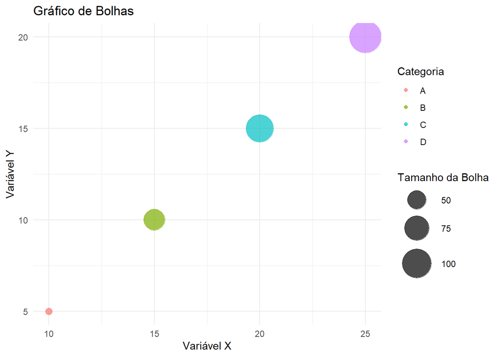

```r
# Instale o pacote ggplot2 se ainda não estiver instalado
# install.packages("ggplot2")

# Carregue o pacote ggplot2
library(ggplot2)

# Crie um conjunto de dados fictício
dados <- data.frame(
  VariavelX = c(10, 15, 20, 25),
  VariavelY = c(5, 10, 15, 20),
  TamanhoBolha = c(30, 60, 90, 120),
  Categoria = c("A", "B", "C", "D")
)

# Crie o gráfico de bolhas
ggplot(dados, aes(x = VariavelX, y = VariavelY, size = TamanhoBolha, color = Categoria)) +
  geom_point(alpha = 0.7) +
  scale_size_continuous(range = c(3, 15)) +
  labs(title = "Gráfico de Bolhas",
       x = "Variável X",
       y = "Variável Y",
       size = "Tamanho da Bolha",
       color = "Categoria") +
  theme_minimal()
```

Variáveis: Qualitativas (categorias) e Quantitativas. Uso: Comparação de várias categorias em termos de múltiplas variáveis quantitativas.